# STA 309 Final

James Kirchenwitz

2024-12-11

# Part One:

```r
# Reading in data
data <- read.csv('diabetes_data.csv')
data <- data %>%
  mutate(gender = as.factor(gender),
         smoking_history = as.factor(smoking_history),
         diabetes = as.factor(diabetes))
#glimpse(data)

# Training the data
dataIndex <- createDataPartition(1:nrow(diamonds), p = 0.8)$Resample1
data_train <- filter(data, row_number() %in% dataIndex)
data_test <- filter(data, !row_number() %in% dataIndex)

ctrl = trainControl(method = 'repeatedcv', number = 5, repeats = 10)


# Deciding what variable are necassary for a best fit
```

## Fitting Three Models

```r
# First is a logistic regression model with all predictors (requirment one)
set.seed(401)
mod.glm <- train(diabetes ~ blood_glucose_level + HbA1c_level + bmi + smoking_history +
                heart_disease + hypertension + age + gender,
                data = data_train,
                method="glm",
                family='binomial',
                trControl=ctrl)
# Deciding what variable are necassary for a best fit
summary(mod.glm)
```

```
##
## Call:
## NULL
##
## Deviance Residuals:
##     Min       1Q   Median       3Q      Max
## -2.3693  -0.2740  -0.0347   0.1796   3.2369
##
## Coefficients:
##                                Estimate Std. Error z value Pr(>|z|)
## (Intercept)                  -25.660129   2.354131 -10.900  < 2e-16 ***
## blood_glucose_level            0.031773   0.004220   7.529 5.13e-14 ***
## HbA1c_level                    2.538591   0.301327   8.425  < 2e-16 ***
## bmi                            0.084186   0.021933   3.838 0.000124 ***
## smoking_historyever           -0.728738   0.815381  -0.894 0.371461
## smoking_historyformer         -0.634705   0.539677  -1.176 0.239562
## smoking_historynever          -0.657909   0.456488  -1.441 0.149516
## `smoking_historyNo Info`      -0.739287   0.488568  -1.513 0.130236
## `smoking_historynot current`  -0.621751   0.629489  -0.988 0.323295
## heart_disease                  1.164959   0.490141   2.377 0.017464 *
## hypertension                   0.960454   0.415204   2.313 0.020711 *
## age                            0.051622   0.007715   6.691 2.22e-11 ***
## genderMale                    -0.342055   0.278664  -1.227 0.219642
## ---
## Signif. codes:  0 '***' 0.001 '**' 0.01 '*' 0.05 '.' 0.1 ' ' 1
##
## (Dispersion parameter for binomial family taken to be 1)
##
##     Null deviance: 1057.82  on 780  degrees of freedom
## Residual deviance:  358.66  on 768  degrees of freedom
## AIC: 384.66
##
## Number of Fisher Scoring iterations: 7
```

```r
# Random forest model (Requirement 2)
set.seed(401)
mod.rf <- train(diabetes ~ blood_glucose_level + HbA1c_level + bmi + smoking_history +
                heart_disease + hypertension + age + gender,
                data = data_train,
                method="rf",
                trControl=ctrl,
                tuneGrid=expand.grid(mtry=1:4),
                importance=TRUE)

# Third other method (Requirement 3, reduced model)
set.seed(401)
mod.nn <- train(diabetes ~ blood_glucose_level + HbA1c_level + bmi + age,
                data=data_train,
                method="nnet",
                tuneGrid=expand.grid(size=3,
                                     decay=c(10,100,1000)),
                trControl=ctrl,
                linout = FALSE)
```

```r
varImp(mod.rf$finalModel)
```

|  | 0 | 1 |
| --- | --- | --- |
| blood_glucose_level | 34.2674378 | 34.2674378 |
| HbA1c_level | 42.6567468 | 42.6567468 |
| bmi | 7.7422440 | 7.7422440 |
| smoking_historyever | -3.0913355 | -3.0913355 |
| smoking_historyformer | 4.2076682 | 4.2076682 |
| smoking_historynever | 0.4277942 | 0.4277942 |
| smoking_historyNo Info | 2.5035301 | 2.5035301 |
| smoking_historynot current | -1.5191062 | -1.5191062 |
| heart_disease | 9.8387449 | 9.8387449 |
| hypertension | 12.6040272 | 12.6040272 |
| age | 22.8528649 | 22.8528649 |
| genderMale | -0.5129853 | -0.5129853 |

### Significant Predictors:

**I utilized the logistic regression model to pick out significant predictors. NOTE: I know there are many better ways like backwords selection, forwards selection, etc., but for simplicity on this final I did not mess around with that. Anyhow, it appears that from the logistic model blood glucose level, HbA1c level, BMI, and age were all significant predictors for predicting diabetes. Additionally I wanted to see what the random forest model outputted as significant. Hemoglobin levels, blood glucose levels, and age are the three most important predictors.**

### Models Predicted:

**I decided to utilize a logistic regression model, a neural network model, and a random forest model. The reasoning behind this is that with a logistic model the computation time is short, and the interpretation of significance is easy to find. The logistic model I used here helped distinguished the significant predictors listed above. The reasoning for a random forest is that I wanted to run a more advanced / complex prediction model. The same rational is present for the neural network, as the neural network along with random forest are more complex.**

# Part Two:

```r
set.seed(401)
a <- resamples(list(LogMod=mod.glm,
               NN=mod.nn,
               RandomForest=mod.rf))
set.seed(401)
summary(resamples(list(LogMod=mod.glm,
                       NN=mod.nn,
                       RandomForest=mod.rf)))
```

```
##
## Call:
## summary.resamples(object = resamples(list(LogMod = mod.glm, NN =
##  mod.nn, RandomForest = mod.rf)))
##
## Models: LogMod, NN, RandomForest
## Number of resamples: 50
##
## Accuracy
##                   Min.   1st Qu.    Median      Mean   3rd Qu.      Max. NA's
## LogMod       0.8205128 0.8717949 0.8881880 0.8834713 0.8974359 0.9171975    0
## NN           0.5897436 0.6891026 0.7115385 0.7095933 0.7435897 0.7820513    0
## RandomForest 0.8269231 0.8782051 0.8910256 0.8900024 0.9102564 0.9299363    0
##
## Kappa
##                   Min.   1st Qu.    Median      Mean   3rd Qu.      Max. NA's
## LogMod       0.6290761 0.7329192 0.7706587 0.7583077 0.7900404 0.8297322    0
## NN           0.0000000 0.3408304 0.3803211 0.3757831 0.4521552 0.5294535    0
## RandomForest 0.6397537 0.7437216 0.7737188 0.7695775 0.8109418 0.8532835    0
```

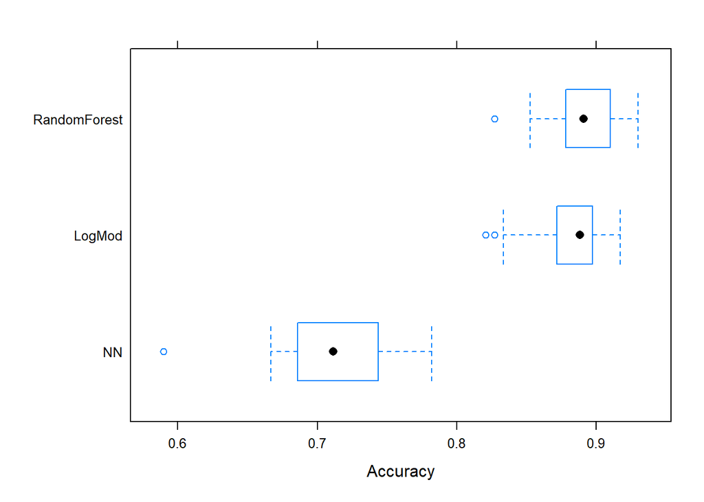

```r
bwplot(a, metric = "Accuracy")
```

```r
# Comparing Models
set.seed(401)
df <- data_test %>%
  mutate(pred.mod.rf = predict(mod.rf, newdata=data_test),
         pred.mod.nn = predict(mod.nn, newdata=data_test),
         pred.mod.glm = predict(mod.glm, newdata=data_test))


#glimpse(df)

# Do this with all data
rf.pred.table <- table(df$pred.mod.rf, df$diabetes)
confusionMatrix(rf.pred.table)
```

```
## Confusion Matrix and Statistics
##
##
##       0   1
##   0 134  19
##   1   6  60
##
##                Accuracy : 0.8858
##                  95% CI : (0.8361, 0.9247)
##     No Information Rate : 0.6393
##     P-Value [Acc > NIR] : <2e-16
##
##                   Kappa : 0.7433
##
##  Mcnemar's Test P-Value : 0.0164
##
##             Sensitivity : 0.9571
##             Specificity : 0.7595
##          Pos Pred Value : 0.8758
##          Neg Pred Value : 0.9091
##              Prevalence : 0.6393
##          Detection Rate : 0.6119
##    Detection Prevalence : 0.6986
##       Balanced Accuracy : 0.8583
##
##        'Positive' Class : 0
##
```

```r
nn.pred.table <- table(df$pred.mod.nn, df$diabetes)
confusionMatrix(nn.pred.table)
```

```
## Confusion Matrix and Statistics
##
##
##       0   1
##   0 118  40
##   1  22  39
##
##                Accuracy : 0.7169
##                  95% CI : (0.6523, 0.7755)
##     No Information Rate : 0.6393
##     P-Value [Acc > NIR] : 0.009233
##
##                   Kappa : 0.3541
##
##  Mcnemar's Test P-Value : 0.030850
##
##             Sensitivity : 0.8429
##             Specificity : 0.4937
##          Pos Pred Value : 0.7468
##          Neg Pred Value : 0.6393
##              Prevalence : 0.6393
##          Detection Rate : 0.5388
##    Detection Prevalence : 0.7215
##       Balanced Accuracy : 0.6683
##
##        'Positive' Class : 0
##
```

```r
log.pred.table <- table(df$pred.mod.glm, df$diabetes)
confusionMatrix(log.pred.table)
```

```
## Confusion Matrix and Statistics
##
##
##       0   1
##   0 129  21
##   1  11  58
##
##                Accuracy : 0.8539
##                  95% CI : (0.8, 0.8979)
##     No Information Rate : 0.6393
##     P-Value [Acc > NIR] : 1.217e-12
##
##                   Kappa : 0.6742
##
##  Mcnemar's Test P-Value : 0.1116
##
##             Sensitivity : 0.9214
##             Specificity : 0.7342
##          Pos Pred Value : 0.8600
##          Neg Pred Value : 0.8406
##              Prevalence : 0.6393
##          Detection Rate : 0.5890
##    Detection Prevalence : 0.6849
##       Balanced Accuracy : 0.8278
##
##        'Positive' Class : 0
##
```

**NOTE: the accuracies keep changing with each iteration of the script, but order of importance stays**